# Project: Investigate a Dataset (IMDB-Movie Dataset)

- Introduction
- Data Wrangling
- Exploratory Data Analysis
- Conclusions

## Introduction

In this project, I will be analysing IMDB movie dataset that contains information about 10,000 movies collected from The Movie Database (IMDb), including user ratings and revenue.

- id: Movie identification number
- tmbd_id: Internet movie database identification number for the movie
- popularity: How viral the movie went
- budget: An estimate income and expendicture for the movie for a particular year
- revenue: Income generated from the movie for a particular year
- original_title: The title name of a particular movie
- cast: People who featured in the movie
- homepage: A page on the website where the movie was found
- director: The director of the movie
- tagline: A short text describing a dramatic (catchy and enticing short phrases) thought of each movie
- keywords: Description of notable object, concept, style or action that takes place in the movie.
- overviews: A brief summary of the movie
- runtime: The duration of the movie
- genres: classification of different categories of movies
- production_companies:Companies that produced the movie
- release_date: Movie released date
- vote_count: Movie rating
- vote_average:Movie rating average
- released_year:The particular year the movie is released

### Question(s) for Analysis

1. Which genre are most popular from year to year?
2. which director has the highest movie popularity and what year?
3. what movie, production company has the highest revenue and what year?

### Importing necessary libraries needed

```python
# importing neccessary libraries
import numpy as np
import pandas as pd
import matplotlib.pyplot as plt
%matplotlib inline
```

## Data Wrangling

### General Properties

```python
# Loading dataset and printing out a few lines.
df = pd.read_csv('imdb-movies.csv')
df.head()
```

|  | id | imdb_id | popularity | budget | revenue | original_title | cast | homepage | director | tagline | ... | overview | runtime | genres | production_companies | release_date | vote_count | vote_average | release_year | budget_adj | revenue_adj |
| --- | --- | --- | --- | --- | --- | --- | --- | --- | --- | --- | --- | --- | --- | --- | --- | --- | --- | --- | --- | --- | --- |
| 0 | 135397 | tt0369610 | 32.985763 | 150000000 | 1513528810 | Jurassic World | Chris Pratt\|Bryce Dallas Howard\|Irrfan Khan\|Vi... | http://www.jurassicworld.com/ | Colin Trevorrow | The park is open. | ... | Twenty-two years after the events of Jurassic ... | 124 | Action\|Adventure\|Science Fiction\|Thriller | Universal Studios\|Amblin Entertainment\|Legenda... | 6/9/15 | 5562 | 6.5 | 2015 | 1.379999e+08 | 1.392446e+09 |
| 1 | 76341 | tt1392190 | 28.419936 | 150000000 | 378436354 | Mad Max: Fury Road | Tom Hardy\|Charlize Theron\|Hugh Keays-Byrne\|Nic... | http://www.madmaxmovie.com/ | George Miller | What a Lovely Day. | ... | An apocalyptic story set in the furthest reach... | 120 | Action\|Adventure\|Science Fiction\|Thriller | Village Roadshow Pictures\|Kennedy Miller Produ... | 5/13/15 | 6185 | 7.1 | 2015 | 1.379999e+08 | 3.481613e+08 |
| 2 | 262500 | tt2908446 | 13.112507 | 110000000 | 295238201 | Insurgent | Shailene Woodley\|Theo James\|Kate Winslet\|Ansel... | http://www.thedivergentseries.movie/#insurgent | Robert Schwentke | One Choice Can Destroy You | ... | Beatrice Prior must confront her inner demons ... | 119 | Adventure\|Science Fiction\|Thriller | Summit Entertainment\|Mandeville Films\|Red Wago... | 3/18/15 | 2480 | 6.3 | 2015 | 1.012000e+08 | 2.716190e+08 |
| 3 | 140607 | tt2488496 | 11.173104 | 200000000 | 2068178225 | Star Wars: The Force Awakens | Harrison Ford\|Mark Hamill\|Carrie Fisher\|Adam D... | http://www.starwars.com/films/star-wars-episod... | J.J. Abrams | Every generation has a story. | ... | Thirty years after defeating the Galactic Empi... | 136 | Action\|Adventure\|Science Fiction\|Fantasy | Lucasfilm\|Truenorth Productions\|Bad Robot | 12/15/15 | 5292 | 7.5 | 2015 | 1.839999e+08 | 1.902723e+09 |
| 4 | 168259 | tt2820852 | 9.335014 | 190000000 | 1506249360 | Furious 7 | Vin Diesel\|Paul Walker\|Jason Statham\|Michelle ... | http://www.furious7.com/ | James Wan | Vengeance Hits Home | ... | Deckard Shaw seeks revenge against Dominic Tor... | 137 | Action\|Crime\|Thriller | Universal Pictures\|Original Film\|Media Rights ... | 4/1/15 | 2947 | 7.3 | 2015 | 1.747999e+08 | 1.385749e+09 |

5 rows × 21 columns

```python
# checking the number of samples and columns in the imdb-movie dataset
df.shape
```

```
(10866, 21)
```

The imdb dataset has initial 10866 samples and 21 columns

```python
# checking for more information about the dataset
# this allowed me to know the exact datatype of variables in the dataset
df.info()
```

```
<class 'pandas.core.frame.DataFrame'>
RangeIndex: 10866 entries, 0 to 10865
Data columns (total 21 columns):
 #   Column                Non-Null Count  Dtype
---  ------                --------------  -----
 0   id                    10866 non-null  int64
 1   imdb_id               10856 non-null  object
 2   popularity            10866 non-null  float64
 3   budget                10866 non-null  int64
 4   revenue               10866 non-null  int64
 5   original_title        10866 non-null  object
 6   cast                  10790 non-null  object
 7   homepage              2936 non-null   object
 8   director              10822 non-null  object
 9   tagline               8042 non-null   object
 10  keywords              9373 non-null   object
 11  overview              10862 non-null  object
 12  runtime               10866 non-null  int64
 13  genres                10843 non-null  object
 14  production_companies  9836 non-null   object
 15  release_date          10866 non-null  object
 16  vote_count            10866 non-null  int64
 17  vote_average          10866 non-null  float64
 18  release_year          10866 non-null  int64
 19  budget_adj            10866 non-null  float64
 20  revenue_adj           10866 non-null  float64
dtypes: float64(4), int64(6), object(11)
memory usage: 1.7+ MB
```

```python
# verifying if the number of columns listed in the introdutory section tally with this.
df.columns
```

```
Index(['id', 'imdb_id', 'popularity', 'budget', 'revenue', 'original_title',
       'cast', 'homepage', 'director', 'tagline', 'keywords', 'overview',
       'runtime', 'genres', 'production_companies', 'release_date',
       'vote_count', 'vote_average', 'release_year', 'budget_adj',
       'revenue_adj'],
      dtype='object')
```

```python
# range of year in consideration
df.release_year.sort_values().unique()
```

```
array([1960, 1961, 1962, 1963, 1964, 1965, 1966, 1967, 1968, 1969, 1970,
       1971, 1972, 1973, 1974, 1975, 1976, 1977, 1978, 1979, 1980, 1981,
       1982, 1983, 1984, 1985, 1986, 1987, 1988, 1989, 1990, 1991, 1992,
       1993, 1994, 1995, 1996, 1997, 1998, 1999, 2000, 2001, 2002, 2003,
       2004, 2005, 2006, 2007, 2008, 2009, 2010, 2011, 2012, 2013, 2014,
       2015], dtype=int64)
```

The year range of the imdb-movie dataset in consideration was from 1960 to 2015

```python
# checking out the statistical infomation about the dataset
df.describe()
```

|  | id | popularity | budget | revenue | runtime | vote_count | vote_average | release_year | budget_adj | revenue_adj |
| --- | --- | --- | --- | --- | --- | --- | --- | --- | --- | --- |
| count | 10866.000000 | 10866.000000 | 1.086600e+04 | 1.086600e+04 | 10866.000000 | 10866.000000 | 10866.000000 | 10866.000000 | 1.086600e+04 | 1.086600e+04 |
| mean | 66064.177434 | 0.646441 | 1.462570e+07 | 3.982332e+07 | 102.070863 | 217.389748 | 5.974922 | 2001.322658 | 1.755104e+07 | 5.136436e+07 |
| std | 92130.136561 | 1.000185 | 3.091321e+07 | 1.170035e+08 | 31.381405 | 575.619058 | 0.935142 | 12.812941 | 3.430616e+07 | 1.446325e+08 |
| min | 5.000000 | 0.000065 | 0.000000e+00 | 0.000000e+00 | 0.000000 | 10.000000 | 1.500000 | 1960.000000 | 0.000000e+00 | 0.000000e+00 |
| 25% | 10596.250000 | 0.207583 | 0.000000e+00 | 0.000000e+00 | 90.000000 | 17.000000 | 5.400000 | 1995.000000 | 0.000000e+00 | 0.000000e+00 |
| 50% | 20669.000000 | 0.383856 | 0.000000e+00 | 0.000000e+00 | 99.000000 | 38.000000 | 6.000000 | 2006.000000 | 0.000000e+00 | 0.000000e+00 |
| 75% | 75610.000000 | 0.713817 | 1.500000e+07 | 2.400000e+07 | 111.000000 | 145.750000 | 6.600000 | 2011.000000 | 2.085325e+07 | 3.369710e+07 |
| max | 417859.000000 | 32.985763 | 4.250000e+08 | 2.781506e+09 | 900.000000 | 9767.000000 | 9.200000 | 2015.000000 | 4.250000e+08 | 2.827124e+09 |

##### The statistical information about all the variables in the dataFrame before data cleaning

This provide a quick insigth to the variables we are working with in the dataframe. considering some of the dependent variables and the independent variables needed for the analysis.

```python
# checking for missing values
print(df.isnull().any())
print ('Total sum of null values: ', df.isnull().any().sum())
```

```
id                      False
imdb_id                  True
popularity              False
budget                  False
revenue                 False
original_title          False
cast                     True
homepage                 True
director                 True
tagline                  True
keywords                 True
overview                 True
runtime                 False
genres                   True
production_companies     True
release_date            False
vote_count              False
vote_average            False
release_year            False
budget_adj              False
revenue_adj             False
dtype: bool
Total sum of null values:  9
```

```python
# more details about null values in each column
# no of null values per variable
df.isnull().sum()
```

```
id                         0
imdb_id                   10
popularity                 0
budget                     0
revenue                    0
original_title             0
cast                      76
homepage                7930
director                  44
tagline                 2824
keywords                1493
overview                   4
runtime                    0
genres                    23
production_companies    1030
release_date               0
vote_count                 0
vote_average               0
release_year               0
budget_adj                 0
revenue_adj                0
dtype: int64
```

There are null values in the imdb dataset. moreover, there are total sum of 9 variables with null values which include imdb_id, cast, homepage, director, tagline, keywords, overview, genres and production_companies

```python
# checking for duplicate rows in the datasets
total_dup = sum(df.duplicated())
(df.duplicated().any(), total_dup)
```

```
(True, 1)
```

There is only one duplicate in the entire imdb movie dataset

### Data Cleaning

After assessing the imdb movie dataset, I discovered that the dataset has a total of 10866 rows and 21 columns. 9 total variables with null values and 1 duplicate. Moreover, the variables are in their exact datatypes

Here are the few problem that needs to be cleaned:

1. The null values
2. Duplicate values
3. Strings seprated with delimeter (|) in some necessary variables consistent with my analysis

#### Droping null values

```python
# droping null values
df.dropna(inplace = True)
```

```python
# verifying if the changes is true
print(df.isnull().sum())
print('There is no null value found in the dataset')
```

```
id                      0
imdb_id                 0
popularity              0
budget                  0
revenue                 0
original_title          0
cast                    0
homepage                0
director                0
tagline                 0
keywords                0
overview                0
runtime                 0
genres                  0
production_companies    0
release_date            0
vote_count              0
vote_average            0
release_year            0
budget_adj              0
revenue_adj             0
dtype: int64
There is no null value found in the dataset
```

#### droping duplicate value

```python
# drop duplicates
df.drop_duplicates(inplace=True)
```

```python
# verifying duplicate value droped
df.duplicated().any()
```

```
False
```

```python
df.shape
```

```
(1992, 21)
```

The total number of samples left over after droping the null values is 1992 out of 10866 samples while the column number remain unchanged

#### Spliting string separated by delimiter

```python
df.head()
```

|  | id | imdb_id | popularity | budget | revenue | original_title | cast | homepage | director | tagline | ... | overview | runtime | genres | production_companies | release_date | vote_count | vote_average | release_year | budget_adj | revenue_adj |
| --- | --- | --- | --- | --- | --- | --- | --- | --- | --- | --- | --- | --- | --- | --- | --- | --- | --- | --- | --- | --- | --- |
| 0 | 135397 | tt0369610 | 32.985763 | 150000000 | 1513528810 | Jurassic World | Chris Pratt\|Bryce Dallas Howard\|Irrfan Khan\|Vi... | http://www.jurassicworld.com/ | Colin Trevorrow | The park is open. | ... | Twenty-two years after the events of Jurassic ... | 124 | Action\|Adventure\|Science Fiction\|Thriller | Universal Studios\|Amblin Entertainment\|Legenda... | 6/9/15 | 5562 | 6.5 | 2015 | 1.379999e+08 | 1.392446e+09 |
| 1 | 76341 | tt1392190 | 28.419936 | 150000000 | 378436354 | Mad Max: Fury Road | Tom Hardy\|Charlize Theron\|Hugh Keays-Byrne\|Nic... | http://www.madmaxmovie.com/ | George Miller | What a Lovely Day. | ... | An apocalyptic story set in the furthest reach... | 120 | Action\|Adventure\|Science Fiction\|Thriller | Village Roadshow Pictures\|Kennedy Miller Produ... | 5/13/15 | 6185 | 7.1 | 2015 | 1.379999e+08 | 3.481613e+08 |
| 2 | 262500 | tt2908446 | 13.112507 | 110000000 | 295238201 | Insurgent | Shailene Woodley\|Theo James\|Kate Winslet\|Ansel... | http://www.thedivergentseries.movie/#insurgent | Robert Schwentke | One Choice Can Destroy You | ... | Beatrice Prior must confront her inner demons ... | 119 | Adventure\|Science Fiction\|Thriller | Summit Entertainment\|Mandeville Films\|Red Wago... | 3/18/15 | 2480 | 6.3 | 2015 | 1.012000e+08 | 2.716190e+08 |
| 3 | 140607 | tt2488496 | 11.173104 | 200000000 | 2068178225 | Star Wars: The Force Awakens | Harrison Ford\|Mark Hamill\|Carrie Fisher\|Adam D... | http://www.starwars.com/films/star-wars-episod... | J.J. Abrams | Every generation has a story. | ... | Thirty years after defeating the Galactic Empi... | 136 | Action\|Adventure\|Science Fiction\|Fantasy | Lucasfilm\|Truenorth Productions\|Bad Robot | 12/15/15 | 5292 | 7.5 | 2015 | 1.839999e+08 | 1.902723e+09 |
| 4 | 168259 | tt2820852 | 9.335014 | 190000000 | 1506249360 | Furious 7 | Vin Diesel\|Paul Walker\|Jason Statham\|Michelle ... | http://www.furious7.com/ | James Wan | Vengeance Hits Home | ... | Deckard Shaw seeks revenge against Dominic Tor... | 137 | Action\|Crime\|Thriller | Universal Pictures\|Original Film\|Media Rights ... | 4/1/15 | 2947 | 7.3 | 2015 | 1.747999e+08 | 1.385749e+09 |

5 rows × 21 columns

#### Writing a function to check for delimiter | in genres, cast, production_companies and director columns to avoid repetitive code

```python
# function to check for the delimiter
def check_delimiter (col_name):
    del_cols = df[col_name].str.contains('|').any()
    return del_cols
```

```python
check_delimiter('genres')
check_delimiter('production_companies')
check_delimiter('cast')
check_delimiter('director')
```

```
True
```

#### Writing a function to split strings separated by delimiter | in genres, cast, production_companies and director columns to avoid repetitive code

```python
# function to split and explode the strings separated by delimiter
def split_explode(df, col_name):
    df[col_name] = df[col_name].str.split('|')
    return (df.explode(col_name))
```

```python
# splitting and exploding variables
df_split_genres = split_explode(df, 'genres')
df_split_cast = split_explode(df_split_genres, 'cast')
df_split_production_companies = split_explode(df_split_cast, 'production_companies')
df_split_director = split_explode(df_split_production_companies, 'director')
df_final_split = df_split_director
df_final_split
```

|  | id | imdb_id | popularity | budget | revenue | original_title | cast | homepage | director | tagline | ... | overview | runtime | genres | production_companies | release_date | vote_count | vote_average | release_year | budget_adj | revenue_adj |
| --- | --- | --- | --- | --- | --- | --- | --- | --- | --- | --- | --- | --- | --- | --- | --- | --- | --- | --- | --- | --- | --- |
| 0 | 135397 | tt0369610 | 32.985763 | 150000000 | 1513528810 | Jurassic World | Chris Pratt | http://www.jurassicworld.com/ | Colin Trevorrow | The park is open. | ... | Twenty-two years after the events of Jurassic ... | 124 | Action | Universal Studios | 6/9/15 | 5562 | 6.5 | 2015 | 1.379999e+08 | 1.392446e+09 |
| 0 | 135397 | tt0369610 | 32.985763 | 150000000 | 1513528810 | Jurassic World | Chris Pratt | http://www.jurassicworld.com/ | Colin Trevorrow | The park is open. | ... | Twenty-two years after the events of Jurassic ... | 124 | Action | Amblin Entertainment | 6/9/15 | 5562 | 6.5 | 2015 | 1.379999e+08 | 1.392446e+09 |
| 0 | 135397 | tt0369610 | 32.985763 | 150000000 | 1513528810 | Jurassic World | Chris Pratt | http://www.jurassicworld.com/ | Colin Trevorrow | The park is open. | ... | Twenty-two years after the events of Jurassic ... | 124 | Action | Legendary Pictures | 6/9/15 | 5562 | 6.5 | 2015 | 1.379999e+08 | 1.392446e+09 |
| 0 | 135397 | tt0369610 | 32.985763 | 150000000 | 1513528810 | Jurassic World | Chris Pratt | http://www.jurassicworld.com/ | Colin Trevorrow | The park is open. | ... | Twenty-two years after the events of Jurassic ... | 124 | Action | Fuji Television Network | 6/9/15 | 5562 | 6.5 | 2015 | 1.379999e+08 | 1.392446e+09 |
| 0 | 135397 | tt0369610 | 32.985763 | 150000000 | 1513528810 | Jurassic World | Chris Pratt | http://www.jurassicworld.com/ | Colin Trevorrow | The park is open. | ... | Twenty-two years after the events of Jurassic ... | 124 | Action | Dentsu | 6/9/15 | 5562 | 6.5 | 2015 | 1.379999e+08 | 1.392446e+09 |
| ... | ... | ... | ... | ... | ... | ... | ... | ... | ... | ... | ... | ... | ... | ... | ... | ... | ... | ... | ... | ... | ... |
| 10819 | 16214 | tt0077696 | 0.044675 | 0 | 78000000 | Hooper | Burt Reynolds | http://en.wikipedia.org/wiki/Hooper_(film) | Hal Needham | The greatest stuntman alive! | ... | Burt Reynolds plays a legendary stunt man know... | 107 | Comedy | Warner Bros. | 7/28/78 | 13 | 6.0 | 1978 | 0.000000e+00 | 2.607307e+08 |
| 10819 | 16214 | tt0077696 | 0.044675 | 0 | 78000000 | Hooper | Robert Klein | http://en.wikipedia.org/wiki/Hooper_(film) | Hal Needham | The greatest stuntman alive! | ... | Burt Reynolds plays a legendary stunt man know... | 107 | Comedy | Warner Bros. | 7/28/78 | 13 | 6.0 | 1978 | 0.000000e+00 | 2.607307e+08 |
| 10819 | 16214 | tt0077696 | 0.044675 | 0 | 78000000 | Hooper | Adam West | http://en.wikipedia.org/wiki/Hooper_(film) | Hal Needham | The greatest stuntman alive! | ... | Burt Reynolds plays a legendary stunt man know... | 107 | Comedy | Warner Bros. | 7/28/78 | 13 | 6.0 | 1978 | 0.000000e+00 | 2.607307e+08 |
| 10819 | 16214 | tt0077696 | 0.044675 | 0 | 78000000 | Hooper | Jan-Michael Vincent | http://en.wikipedia.org/wiki/Hooper_(film) | Hal Needham | The greatest stuntman alive! | ... | Burt Reynolds plays a legendary stunt man know... | 107 | Comedy | Warner Bros. | 7/28/78 | 13 | 6.0 | 1978 | 0.000000e+00 | 2.607307e+08 |
| 10819 | 16214 | tt0077696 | 0.044675 | 0 | 78000000 | Hooper | Sally Field | http://en.wikipedia.org/wiki/Hooper_(film) | Hal Needham | The greatest stuntman alive! | ... | Burt Reynolds plays a legendary stunt man know... | 107 | Comedy | Warner Bros. | 7/28/78 | 13 | 6.0 | 1978 | 0.000000e+00 | 2.607307e+08 |

81094 rows × 21 columns

#### Reading the new cleaned dataframe into csv

```python
df_final_split.to_csv('imdb-movie_cleaned.csv', index=False)
```

#### Loading in the new dataframe

```python
# loading the new dataset and displaying few rows
df_cleaned = pd.read_csv ('imdb-movie_cleaned.csv')
df_cleaned.head()
```

|  | id | imdb_id | popularity | budget | revenue | original_title | cast | homepage | director | tagline | ... | overview | runtime | genres | production_companies | release_date | vote_count | vote_average | release_year | budget_adj | revenue_adj |
| --- | --- | --- | --- | --- | --- | --- | --- | --- | --- | --- | --- | --- | --- | --- | --- | --- | --- | --- | --- | --- | --- |
| 0 | 135397 | tt0369610 | 32.985763 | 150000000 | 1513528810 | Jurassic World | Chris Pratt | http://www.jurassicworld.com/ | Colin Trevorrow | The park is open. | ... | Twenty-two years after the events of Jurassic ... | 124 | Action | Universal Studios | 6/9/15 | 5562 | 6.5 | 2015 | 1.379999e+08 | 1.392446e+09 |
| 1 | 135397 | tt0369610 | 32.985763 | 150000000 | 1513528810 | Jurassic World | Chris Pratt | http://www.jurassicworld.com/ | Colin Trevorrow | The park is open. | ... | Twenty-two years after the events of Jurassic ... | 124 | Action | Amblin Entertainment | 6/9/15 | 5562 | 6.5 | 2015 | 1.379999e+08 | 1.392446e+09 |
| 2 | 135397 | tt0369610 | 32.985763 | 150000000 | 1513528810 | Jurassic World | Chris Pratt | http://www.jurassicworld.com/ | Colin Trevorrow | The park is open. | ... | Twenty-two years after the events of Jurassic ... | 124 | Action | Legendary Pictures | 6/9/15 | 5562 | 6.5 | 2015 | 1.379999e+08 | 1.392446e+09 |
| 3 | 135397 | tt0369610 | 32.985763 | 150000000 | 1513528810 | Jurassic World | Chris Pratt | http://www.jurassicworld.com/ | Colin Trevorrow | The park is open. | ... | Twenty-two years after the events of Jurassic ... | 124 | Action | Fuji Television Network | 6/9/15 | 5562 | 6.5 | 2015 | 1.379999e+08 | 1.392446e+09 |
| 4 | 135397 | tt0369610 | 32.985763 | 150000000 | 1513528810 | Jurassic World | Chris Pratt | http://www.jurassicworld.com/ | Colin Trevorrow | The park is open. | ... | Twenty-two years after the events of Jurassic ... | 124 | Action | Dentsu | 6/9/15 | 5562 | 6.5 | 2015 | 1.379999e+08 | 1.392446e+09 |

5 rows × 21 columns

#### verifying if the delimiter | in genres, cast, production_companies and director columns is removed

```python
# verifying if the delimiter is removed from the genres variable
df['genres'].str.contains('|').any()
```

```
False
```

```python
# verifying if the delimiter is removed from the cast variable
df_split_genres['cast'].str.contains('|').any()
```

```
False
```

```python
# verifying if the delimiter is removed from the production_companies variable
df_split_cast['production_companies'].str.contains('|').any()
```

```
False
```

```python
# verifying if the delimiter is removed from the director variable
df_split_production_companies['director'].str.contains('|').any()
```

```
False
```

```python
# info amout the cleaned dataframe
df_cleaned.info()
```

```
<class 'pandas.core.frame.DataFrame'>
RangeIndex: 81094 entries, 0 to 81093
Data columns (total 21 columns):
 #   Column                Non-Null Count  Dtype
---  ------                --------------  -----
 0   id                    81094 non-null  int64
 1   imdb_id               81094 non-null  object
 2   popularity            81094 non-null  float64
 3   budget                81094 non-null  int64
 4   revenue               81094 non-null  int64
 5   original_title        81094 non-null  object
 6   cast                  81094 non-null  object
 7   homepage              81094 non-null  object
 8   director              81094 non-null  object
 9   tagline               81094 non-null  object
 10  keywords              81094 non-null  object
 11  overview              81094 non-null  object
 12  runtime               81094 non-null  int64
 13  genres                81094 non-null  object
 14  production_companies  81094 non-null  object
 15  release_date          81094 non-null  object
 16  vote_count            81094 non-null  int64
 17  vote_average          81094 non-null  float64
 18  release_year          81094 non-null  int64
 19  budget_adj            81094 non-null  float64
 20  revenue_adj           81094 non-null  float64
dtypes: float64(4), int64(6), object(11)
memory usage: 13.0+ MB
```

```python
# statistical info about the new dataframe
df_cleaned.describe()
```

|  | id | popularity | budget | revenue | runtime | vote_count | vote_average | release_year | budget_adj | revenue_adj |
| --- | --- | --- | --- | --- | --- | --- | --- | --- | --- | --- |
| count | 81094.000000 | 81094.000000 | 8.109400e+04 | 8.109400e+04 | 81094.000000 | 81094.000000 | 81094.000000 | 81094.000000 | 8.109400e+04 | 8.109400e+04 |
| mean | 64931.635608 | 1.610495 | 4.622342e+07 | 1.487667e+08 | 110.204281 | 830.380213 | 6.207462 | 2008.029053 | 4.787163e+07 | 1.617166e+08 |
| std | 85279.370418 | 2.226840 | 5.564308e+07 | 2.491878e+08 | 44.785811 | 1209.102664 | 0.841163 | 6.904566 | 5.588238e+07 | 2.748842e+08 |
| min | 11.000000 | 0.000620 | 0.000000e+00 | 0.000000e+00 | 0.000000 | 10.000000 | 2.100000 | 1961.000000 | 0.000000e+00 | 0.000000e+00 |
| 25% | 8714.250000 | 0.495308 | 3.000000e+06 | 6.235280e+05 | 94.000000 | 92.000000 | 5.700000 | 2006.000000 | 3.000000e+06 | 6.044468e+05 |
| 50% | 27576.000000 | 0.992316 | 2.500000e+07 | 4.946990e+07 | 104.000000 | 325.000000 | 6.200000 | 2009.000000 | 2.808100e+07 | 5.129772e+07 |
| 75% | 77174.000000 | 1.910465 | 7.000000e+07 | 1.802741e+08 | 117.000000 | 1027.000000 | 6.800000 | 2012.000000 | 7.273568e+07 | 1.960861e+08 |
| max | 414419.000000 | 32.985763 | 4.250000e+08 | 2.781506e+09 | 705.000000 | 9767.000000 | 8.300000 | 2015.000000 | 4.250000e+08 | 2.827124e+09 |

##### The statistical information about all the variables in the dataFrame after data cleaning

There is an increase in the statistical values of each variable in the dataframe based on the data Wrangling process. considering again some of the dependent variables and the independent variables needed for the analysis.

```python
# checking the shape of the new dataframe
df_cleaned.shape
```

```
(81094, 21)
```

## Exploratory Data Analysis

### Research Question 1 (Which genre are most popular from year to year?)

#### Exploiring with visuals

```python
# loading cleaned dataframe
df_cleaned = pd.read_csv ('imdb-movie_cleaned.csv')
df_cleaned.head()
```

|  | id | imdb_id | popularity | budget | revenue | original_title | cast | homepage | director | tagline | ... | overview | runtime | genres | production_companies | release_date | vote_count | vote_average | release_year | budget_adj | revenue_adj |
| --- | --- | --- | --- | --- | --- | --- | --- | --- | --- | --- | --- | --- | --- | --- | --- | --- | --- | --- | --- | --- | --- |
| 0 | 135397 | tt0369610 | 32.985763 | 150000000 | 1513528810 | Jurassic World | Chris Pratt | http://www.jurassicworld.com/ | Colin Trevorrow | The park is open. | ... | Twenty-two years after the events of Jurassic ... | 124 | Action | Universal Studios | 6/9/15 | 5562 | 6.5 | 2015 | 1.379999e+08 | 1.392446e+09 |
| 1 | 135397 | tt0369610 | 32.985763 | 150000000 | 1513528810 | Jurassic World | Chris Pratt | http://www.jurassicworld.com/ | Colin Trevorrow | The park is open. | ... | Twenty-two years after the events of Jurassic ... | 124 | Action | Amblin Entertainment | 6/9/15 | 5562 | 6.5 | 2015 | 1.379999e+08 | 1.392446e+09 |
| 2 | 135397 | tt0369610 | 32.985763 | 150000000 | 1513528810 | Jurassic World | Chris Pratt | http://www.jurassicworld.com/ | Colin Trevorrow | The park is open. | ... | Twenty-two years after the events of Jurassic ... | 124 | Action | Legendary Pictures | 6/9/15 | 5562 | 6.5 | 2015 | 1.379999e+08 | 1.392446e+09 |
| 3 | 135397 | tt0369610 | 32.985763 | 150000000 | 1513528810 | Jurassic World | Chris Pratt | http://www.jurassicworld.com/ | Colin Trevorrow | The park is open. | ... | Twenty-two years after the events of Jurassic ... | 124 | Action | Fuji Television Network | 6/9/15 | 5562 | 6.5 | 2015 | 1.379999e+08 | 1.392446e+09 |
| 4 | 135397 | tt0369610 | 32.985763 | 150000000 | 1513528810 | Jurassic World | Chris Pratt | http://www.jurassicworld.com/ | Colin Trevorrow | The park is open. | ... | Twenty-two years after the events of Jurassic ... | 124 | Action | Dentsu | 6/9/15 | 5562 | 6.5 | 2015 | 1.379999e+08 | 1.392446e+09 |

5 rows × 21 columns

### Exploring popularity, released_year, runtime and vote_count column with histogram

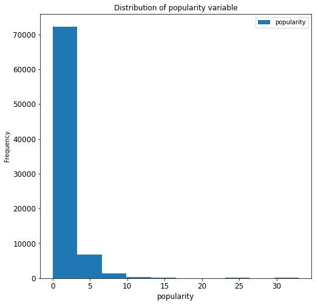

```python
# checking the distribution of popularity variable
df_cleaned.popularity.plot(kind = 'hist', fontsize = 12, legend = 'popularity',
                           title = 'Distribution of popularity variable', figsize = (8,8))
plt.xlabel('popularity', fontsize = 12);
```

Popularity variable skewed to the rigth and lower percentage of popularity values (0 to about 3.4) are more in the dataframe

```python
# checking to verify the histogram distribution of popularity variable
df_cleaned['popularity'].value_counts().head(20).sort_values(ascending = False)
```

```
0.757082    450
0.456683    360
0.340571    300
0.493944    300
3.327799    250
0.966959    250
0.748763    225
2.191033    225
1.265401    200
1.323511    200
0.464885    180
1.107689    175
6.189369    160
2.918566    150
0.848090    150
0.696406    150
2.805019    150
0.439101    150
1.481016    150
2.478372    150
Name: popularity, dtype: int64
```

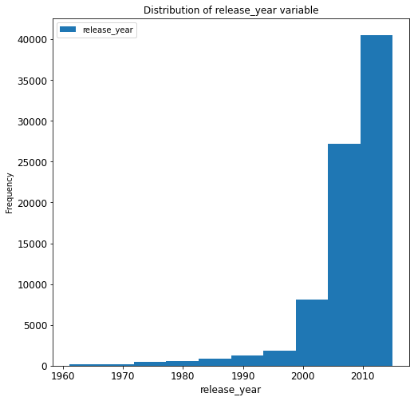

```python
# checking the distribution of release_year variable
df_cleaned.release_year.plot(kind = 'hist', fontsize = 12, legend = 'release_year',
                           title = 'Distribution of release_year variable', figsize = (8,8))
plt.xlabel('release_year', fontsize = 12);
```

The histogram distribution plot of released_year shows is skewed to the left And most of the imdb movie in this dataset was realeased in year 2002 to 2015

```python
# checking to verify the histogram distribution of released_year variable
df_cleaned.release_year.value_counts().head(20)
```

```
2011    8900
2010    8260
2009    8228
2015    6713
2012    6076
2008    5844
2007    5780
2014    5619
2013    4975
2006    4035
2005    3266
2004    2415
2002    1590
2003    1484
2001    1150
1999     800
2000     640
1996     505
1998     500
1997     340
Name: release_year, dtype: int64
```

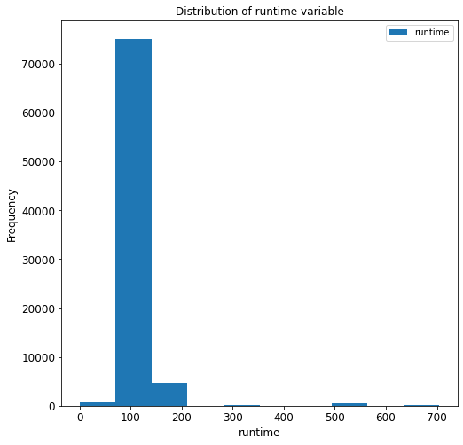

```python
# checking the distribution of runtime variable
df_cleaned.runtime.plot(kind = 'hist', fontsize = 12, legend = 'runtime',
                           title = 'Distribution of runtime variable', figsize = (8,8))
plt.xlabel('runtime', fontsize = 12)
plt.ylabel('Frequency', fontsize = 12);
```

runtime variable is skewed to the right. There are more runtime of 90, 94, 95, 97, 98, 100, 108 in the dataframe

```python
# checking to verify the histogram distribution of runtime variable
df_cleaned.runtime.value_counts().head(20)
```

```
100    2655
90     2645
95     2250
97     2220
108    2120
98     2092
94     2019
93     1949
96     1920
107    1911
102    1882
101    1865
91     1822
92     1821
109    1775
105    1728
106    1674
99     1653
88     1645
124    1630
Name: runtime, dtype: int64
```

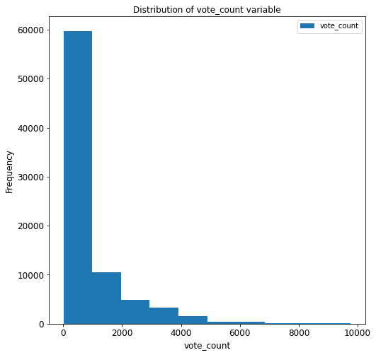

```python
# checking the distribution of vote_count variable
df_cleaned.vote_count.plot(kind = 'hist', fontsize = 12, legend = 'vote_count',
                           title = 'Distribution of vote_count variable',figsize = (8,8))
plt.xlabel('vote_count', fontsize = 12)
plt.ylabel('Frequency', fontsize = 12);
```

```python
# checking to verify the histogram distribution of runtime variable
df_cleaned.runtime.value_counts().head(20)
```

```
100    2655
90     2645
95     2250
97     2220
108    2120
98     2092
94     2019
93     1949
96     1920
107    1911
102    1882
101    1865
91     1822
92     1821
109    1775
105    1728
106    1674
99     1653
88     1645
124    1630
Name: runtime, dtype: int64
```

Vote_count variable is skewed to the right

### Exploring the corelation between genres and popularity, release_year, runtime and vote_count column with Scatter plot

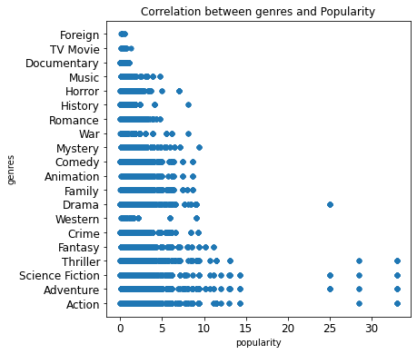

```python
# using scatter plot to show the correlation between genres and popularity
df_cleaned.plot(x = "popularity", y = "genres", kind = "scatter", fontsize = 12,
                title = 'Correlation between genres and Popularity', figsize = (6,6));
```

This shows that popularity has weak correlation with genres variable

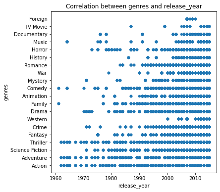

```python
# using scatter plot to show the correlation between genres and release_year
df_cleaned.plot(x = "release_year", y = "genres", kind = "scatter",
                title = 'Correlation between genres and release_year', figsize = (6,6));
```

It appears the release_year is more strong in terms of correlation with genres variable

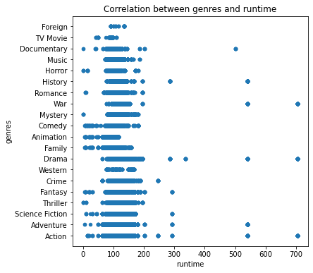

```python
# using scatter plot to show the correlation between genres and runtime
df_cleaned.plot(x = "runtime", y = "genres", kind = "scatter",
                title = 'Correlation between genres and runtime', figsize = (6,6));
```

runtime is more weak in terms of correlation with genres variable

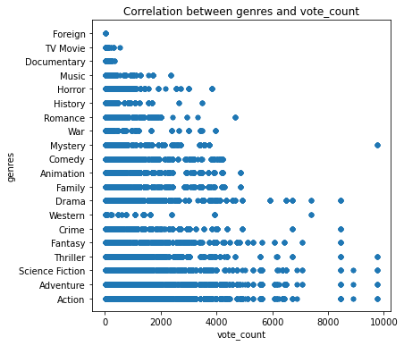

```python
# using scatter plot to show the correlation between genres and vote_count
df_cleaned.plot(x = "vote_count", y = "genres", kind = "scatter",
                title = 'Correlation between genres and vote_count', figsize = (6,6));
```

vote_count has a strong correlation with genres variable

### Research Question 1 (Which genre are most popular from year to year?)

### Using Pandas Groupby

```python
# using pandas groupby approach to group the genres and popularity max
pop_genres = df_cleaned.groupby( 'genres')['popularity'].max()
pop_genres_sort = pop_genres.sort_values(ascending = False)
pop_genres_sort
```

```
genres
Action             32.985763
Thriller           32.985763
Science Fiction    32.985763
Adventure          32.985763
Drama              24.949134
Fantasy            11.173104
Mystery             9.363643
Crime               9.335014
Western             9.110700
Family              8.691294
Comedy              8.691294
Animation           8.691294
War                 8.110711
History             8.110711
Horror              7.031452
Music               4.780419
Romance             4.710402
TV Movie            1.223392
Documentary         1.005772
Foreign             0.534927
Name: popularity, dtype: float64
```

```python
# the top 4 most popular genres
most_pop_genres = pop_genres_sort.head(4)
most_pop_genres
```

```
genres
Action             32.985763
Thriller           32.985763
Science Fiction    32.985763
Adventure          32.985763
Name: popularity, dtype: float64
```

We have total of 4 genres with the highest popularity from year to year with same popularity value of 32.985763. The 4 genres include Action, Adventure, Science fiction and Thriller

### Ploting the popularity of genres with matplotlib

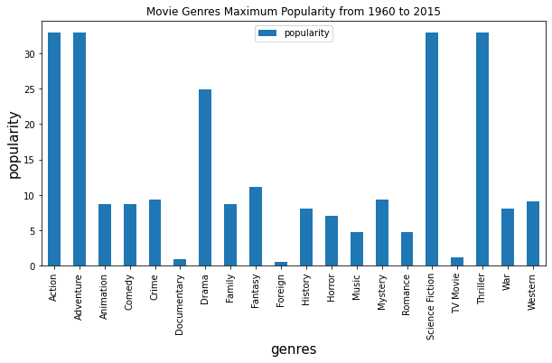

```python
# A bar plot representation of genres popularity
pop_genres.plot(kind = 'bar', figsize = (10,5))

plt.title("Movie Genres Maximum Popularity from 1960 to 2015")
plt.legend()
plt.xlabel('genres', fontsize=15)
plt.ylabel('popularity', fontsize=15);
```

### Research Question 2 (which director has the highest movie popularity and what year?)

```python
# checking count of directors in the dataframe
df_cleaned.director.value_counts()
```

```
John Carpenter       775
Steven Soderbergh    560
Ridley Scott         475
Christopher Nolan    455
Robert Zemeckis      445
                    ...
Laurieann Gibson       1
Dmitry Vasyukov        1
John Moffitt           1
Josh Fox               1
Chris Rock             1
Name: director, Length: 1444, dtype: int64
```

```python
# using groupby to group director, original_title and release_year with maximum popularity
director_max_pop = df_cleaned.groupby(['director', 'release_year', 'original_title'])['popularity'].max()
director_max_pop_sort = director_max_pop.sort_values(ascending = False)
director_max_pop_sort
```

```
director           release_year  original_title
Colin Trevorrow    2015          Jurassic World                   32.985763
George Miller      2015          Mad Max: Fury Road               28.419936
Christopher Nolan  2014          Interstellar                     24.949134
James Gunn         2014          Guardians of the Galaxy          14.311205
Robert Schwentke   2015          Insurgent                        13.112507
                                                                    ...
Woo-sang Park      1987          Miami Connection                  0.005529
Kristopher Belman  2008          More Than a Game                  0.005391
John Moffitt       2009          Jim Jefferies: I Swear to God     0.003432
Kirby Dick         2012          The Invisible War                 0.001372
Darren Stein       2013          G.B.F.                            0.000620
Name: popularity, Length: 2219, dtype: float64
```

```python
# filtering the director with highest popularity
director_max_pop_sort.head(1)
```

```
director         release_year  original_title
Colin Trevorrow  2015          Jurassic World    32.985763
Name: popularity, dtype: float64
```

The director who has the highest popular movie was Colin Trevorrow with popularity rating of 32.985763. The movie was released in the year 2015, with original title 'Jurassic World'

#### Using Visuals to show the top 30 directors who has highest movie popularity

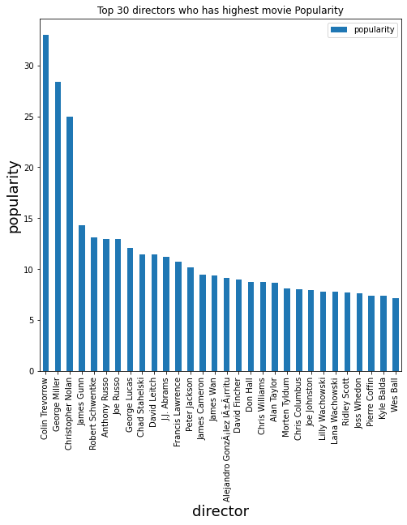

```python
# getting top 30 directors with highest movie popularity
director_max_pop = df_cleaned.groupby(['director'])['popularity'].max()
top_30_director = director_max_pop.sort_values(ascending = False).head(30)

top_30_director.plot(x = 'director', y = 'popularity', kind = 'bar', legend = 'popularity', figsize = (8,8))
plt.title('Top 30 directors who has highest movie Popularity')
plt.xlabel('director', fontsize=18)
plt.ylabel('popularity', fontsize=18);
```

### Research Question 3 (what movie, production company has the highest revenue and what year?)

### checking for the correlation between revenue and release_year

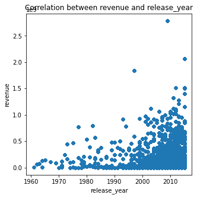

```python
# correlation between revenue and release_year
df_cleaned.plot(x = 'release_year', y = 'revenue', kind= 'scatter',
                title = 'Correlation between revenue and release_year', figsize = (5,5));
```

It was observed that release_year has a positive correlation with revenue. There are more revenue between the year 2000 to 2015

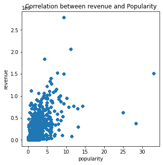

```python
# correlation between revenue and popularity
df_cleaned.plot(x = 'popularity', y = 'revenue', kind= 'scatter',
                title = 'Correlation between revenue and Popularity', figsize = (5,5));
```

It was observed also that popularity has a positive correlation with revenue. There are more revenue between popularity of 0 to about 6

### using Pandas Grouping to return the highest Revenue

```python
# grouping movie title, production_companies
max_rev = df_cleaned.groupby(['original_title', 'production_companies', 'release_year'])['revenue'].max()
highest_rev_sort = max_rev.sort_values(ascending = False)
highest_rev_sort
```

```
original_title                production_companies                    release_year
Avatar                        Ingenious Film Partners                 2009            2781505847
                              Dune Entertainment                      2009            2781505847
                              Twentieth Century Fox Film Corporation  2009            2781505847
                              Lightstorm Entertainment                2009            2781505847
Star Wars: The Force Awakens  Truenorth Productions                   2015            2068178225
                                                                                         ...
Incendiary                    Capitol Films                           2008                     0
                              UK Film Council                         2008                     0
                              Wild Bear Films                         2008                     0
Infini                        Eclectik Vision                         2015                     0
ì˜í˜•ì œ                      Showbox                                 2010                     0
Name: revenue, Length: 5674, dtype: int64
```

```python
# filtering to fetch the movie with highest revenue
highest_rev_sort.head(4)
```

```
original_title  production_companies                    release_year
Avatar          Ingenious Film Partners                 2009            2781505847
                Dune Entertainment                      2009            2781505847
                Twentieth Century Fox Film Corporation  2009            2781505847
                Lightstorm Entertainment                2009            2781505847
Name: revenue, dtype: int64
```

#### Using Visuals to show the top 20 movies that has highest revenue with thier production_companies and year respectively

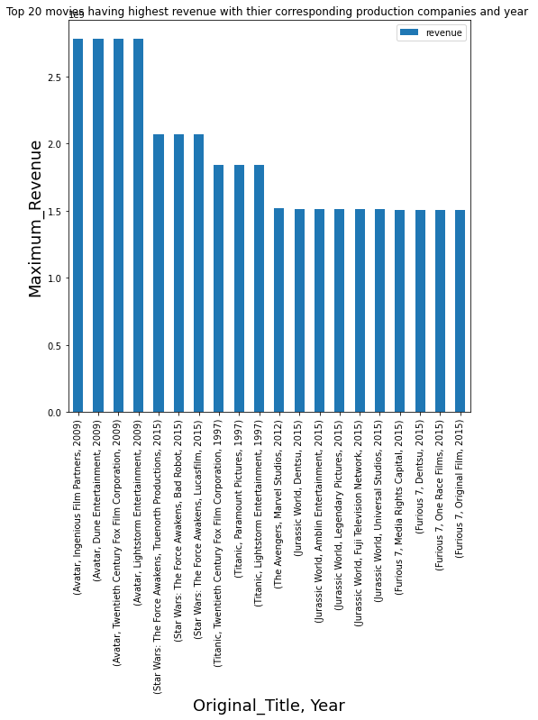

```python
# getting top 20 original_title, production_companies with highest revenue with thier corresponding year
max_rev = df_cleaned.groupby(['original_title', 'production_companies', 'release_year'])['revenue'].max()
top_20_max_rev = max_rev.sort_values(ascending = False).head(20)

top_20_max_rev.plot(kind = 'bar', figsize = (8,8), legend = 'year')

plt.title('Top 20 movies having highest revenue with thier corresponding production companies and year ')
plt.xlabel('Original_Title, Year', fontsize=18)
plt.ylabel('Maximum_Revenue', fontsize=18);
```

Avatar has the highest revenue of 2781505847 in the year 2009. The movie(Avatar) was produced by 4 movie production companies namely;

- Ingenious Film Partners
- Dune Entertainment
- Twentieth Century Fox Film Corporation
- Lightstorm Entertainment

The 4 companies all made the production in the year 2009 with same revenue of 2781505847

## Conclusions

#### Findings Report:

- The year range of the imdb-movie dataset in consideration was from 1961 to 2015
- More Popularity of 0 to about 3.4 are more in the imdb-movie dataframe
- Most of the imdb-movies were released between the year 2002 and 2015
- Most of the imdb-movies released have runtime ranging from 90 to 100
- It was observed that the year of release has strong correlation with genres.

#### Result Report:

- Using pandas groupby approach to group the genres and the maximum population I was able to find out total of 4 genres with the highest popularity from year to year with same popularity value of 32.985763. The 4 genres include Action, Adventure, Science fiction and Thriller.
- Same approach was used to filter the director who has the highest movie popularity and corresponding year. The director who has the highest popular movie was Colin Trevorrow with popularity rating of 32.985763. The movie was released in the year 2015, with the original title 'Jurassic World'.
- In conclusion, in an attempt to find out what movie, production company has the highest revenue and the corresponding year, It was observed that release_year has a strong positive correlation with revenue. There are more revenue between the year 2000 and 2015. It was also observed that popularity has a positive correlation with revenue. There are more revenue between popularity of 0 to about 6. However, based on my analysis, Avatar has the highest revenue of 2781505847 in the year 2009 and for the record, it was the highest from year 1961 to 2015. The movie(Avatar) was produced by 4 movie production companies namely;
- Ingenious Film Partners
- Dune Entertainment
- Twentieth Century Fox Film Corporation
- Lightstorm Entertainment.

The 4 companies all made the production in the year 2009 with same revenue of 2781505847

#### Limitation:

- I could not plot a bar chart representation for all the samples in the dataframe in relation with my analysis question due to large dataframe.